# W7 STAT5003 RMD

Victor Z. Nygaard, vnyg7406

Last compiled on 28. januar, 2023

# 1

We load in `mice` and the data

```r
library(mice)
cancer <- read.csv('../Data/skin-cancer.csv')
head(cancer)
```

```
##   Mort  Lat
## 1  219 33.0
## 2  160 34.5
## 3  170 35.0
## 4  182 37.5
## 5  149 39.0
## 6  159 41.8
```

We may calculate and plot a linear regression

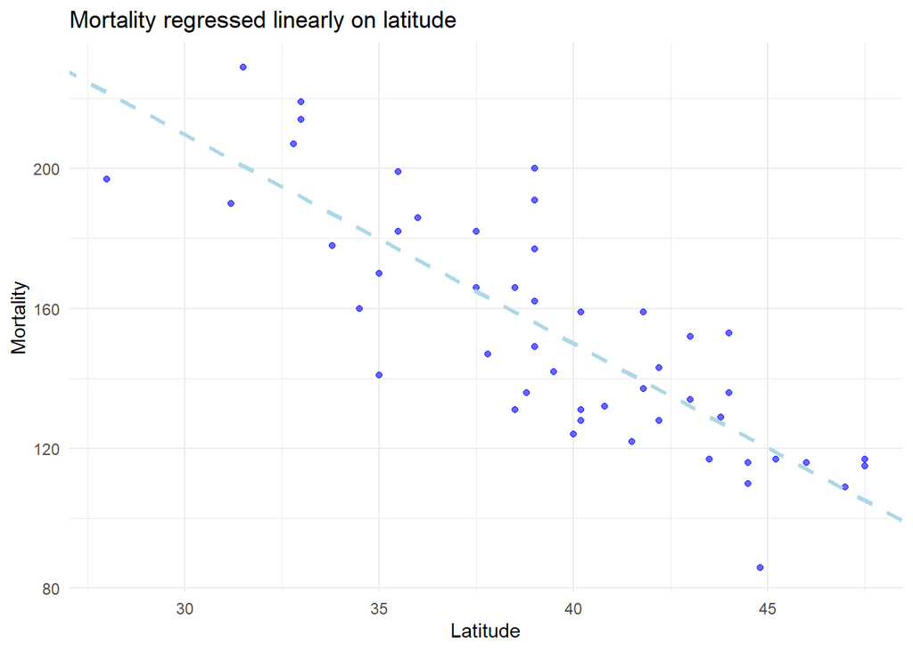

```r
model <- lm(Mort ~ Lat, data = cancer)
coef_model <- as.numeric(coef(model))

(p0 <- cancer %>% ggplot(mapping = aes(x = Lat, y = Mort)) + geom_point(colour = "blue", alpha = 0.6) + geom_abline(size = 1.2, colour = "light blue", linetype = "dashed", slope = coef_model[2], intercept = coef_model[1]) + ggtitle("Mortality regressed linearly on latitude") + labs(x = 'Latitude', y = 'Mortality'))
```

We may see summary statistics of the regression output via

```r
summary(model)
```

```
##
## Call:
## lm(formula = Mort ~ Lat, data = cancer)
##
## Residuals:
##     Min      1Q  Median      3Q     Max
## -38.972 -13.185   0.972  12.006  43.938
##
## Coefficients:
##             Estimate Std. Error t value Pr(>|t|)
## (Intercept) 389.1894    23.8123   16.34  < 2e-16 ***
## Lat          -5.9776     0.5984   -9.99 3.31e-13 ***
## ---
## Signif. codes:  0 '***' 0.001 '**' 0.01 '*' 0.05 '.' 0.1 ' ' 1
##
## Residual standard error: 19.12 on 47 degrees of freedom
## Multiple R-squared:  0.6798, Adjusted R-squared:  0.673
## F-statistic:  99.8 on 1 and 47 DF,  p-value: 3.309e-13
```

In particular we note that the regression coefficients indicate that higher latitude yields lower cancer rates at a rate of -5.9776357 number of cancer deaths incidents per $10$ million people for each degree of latitude increase.

We may emulate MAR missingness (default value of `ampute`) using `ampute`

```r
cancer_amp <- cancer %>% ampute(prop = 0.5, patterns = c(1,0));cancer_amp <- cancer_amp$amp
```

We may regress `Lat` on `Mort` with the amputed data.

```r
inv_model_amp <- lm(Lat ~ Mort, data = cancer_amp)
```

We may take a look at the summary statistics of this model:

```r
summary(inv_model_amp)
```

```
##
## Call:
## lm(formula = Lat ~ Mort, data = cancer_amp)
##
## Residuals:
##     Min      1Q  Median      3Q     Max
## -3.4907 -2.2713  0.1902  1.5729  3.8673
##
## Coefficients:
##             Estimate Std. Error t value Pr(>|t|)
## (Intercept) 57.35453    2.52098  22.751  < 2e-16 ***
## Mort        -0.11728    0.01801  -6.511 9.83e-07 ***
## ---
## Signif. codes:  0 '***' 0.001 '**' 0.01 '*' 0.05 '.' 0.1 ' ' 1
##
## Residual standard error: 2.248 on 24 degrees of freedom
##   (23 observations deleted due to missingness)
## Multiple R-squared:  0.6385, Adjusted R-squared:  0.6235
## F-statistic:  42.4 on 1 and 24 DF,  p-value: 9.825e-07
```

We may also do a linear regression of the mortality on the latitude using the non-missing values of the amputed data:

```r
model_amp <- lm(Mort ~ Lat, data  = cancer_amp)
```

We may once again take a look at the summary statistics for the implemented model:

```r
summary(model_amp)
```

```
##
## Call:
## lm(formula = Mort ~ Lat, data = cancer_amp)
##
## Residuals:
##     Min      1Q  Median      3Q     Max
## -32.165  -9.019   0.478  11.409  27.256
##
## Coefficients:
##             Estimate Std. Error t value Pr(>|t|)
## (Intercept) 362.0824    34.5741  10.473 1.98e-10 ***
## Lat          -5.4446     0.8362  -6.511 9.83e-07 ***
## ---
## Signif. codes:  0 '***' 0.001 '**' 0.01 '*' 0.05 '.' 0.1 ' ' 1
##
## Residual standard error: 15.32 on 24 degrees of freedom
##   (23 observations deleted due to missingness)
## Multiple R-squared:  0.6385, Adjusted R-squared:  0.6235
## F-statistic:  42.4 on 1 and 24 DF,  p-value: 9.825e-07
```

We in particular see from this model that we get a different estimates of the intercept and slope coefficients than we did in `model`.

```r
mort_for_missing_lat <- cancer_amp %>% filter(is.na(Lat)) %>% dplyr::select(Mort)
pred_lat_from_mort <- predict(inv_model_amp, newdata = mort_for_missing_lat) + rnorm(nrow(mort_for_missing_lat), sd = sigma(inv_model_amp))
cancer_amp_imp <- cancer_amp
cancer_amp_imp$Lat[is.na(cancer_amp_imp$Lat)] <- pred_lat_from_mort %>% unname()

attr(cancer_amp_imp, "name") <- "Imputed data"
```

We may see what linear model will be fitted using the imputed data:

```r
model_imputed_data <- lm(Mort ~ Lat, data = cancer_amp_imp)
summary(model_imputed_data)
```

```
##
## Call:
## lm(formula = Mort ~ Lat, data = cancer_amp_imp)
##
## Residuals:
##     Min      1Q  Median      3Q     Max
## -32.755 -12.572   0.415  12.502  30.839
##
## Coefficients:
##             Estimate Std. Error t value Pr(>|t|)
## (Intercept)  415.970     21.511   19.34  < 2e-16 ***
## Lat           -6.668      0.542  -12.30 2.64e-16 ***
## ---
## Signif. codes:  0 '***' 0.001 '**' 0.01 '*' 0.05 '.' 0.1 ' ' 1
##
## Residual standard error: 16.44 on 47 degrees of freedom
## Multiple R-squared:  0.7631, Adjusted R-squared:  0.7581
## F-statistic: 151.4 on 1 and 47 DF,  p-value: 2.641e-16
```

We may compare `model_imputed_data` with `model`:

```r
data.frame(type = c("Intercept", "slope"), data_model = as.numeric(coef_model), imputed_model = as.numeric(coef(model_imputed_data))) %>% column_to_rownames('type')
```

```
##           data_model imputed_model
## Intercept 389.189351    415.970197
## slope      -5.977636     -6.668528
```

We may also plot the imputed model in comparison with the old (noting that we add a small jitter in order to see the half of the original data that is the same as for the imputed)

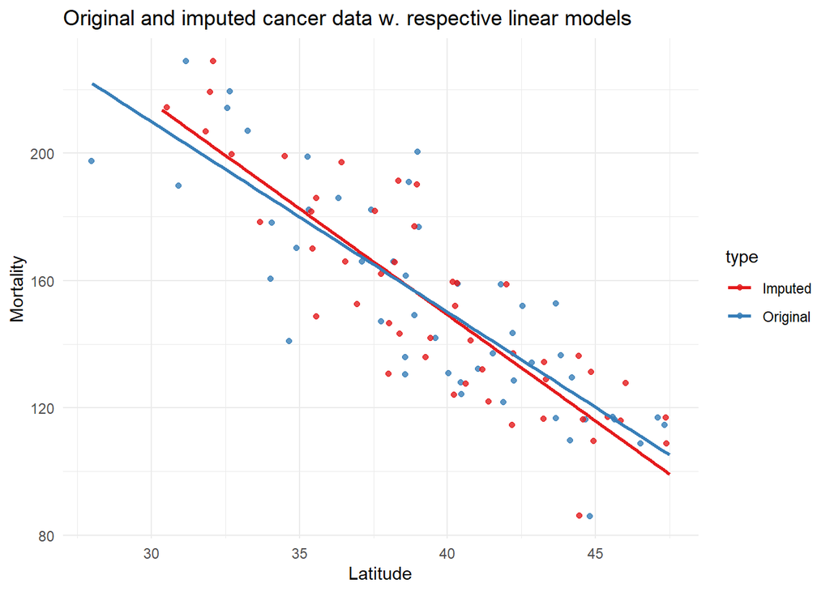

```r
combined_cancer <- bind_cols(bind_rows(cancer, cancer_amp_imp), type = c(rep("Original", nrow(cancer)),rep("Imputed", nrow(cancer))))
combined_cancer %>% ggplot(mapping = aes(x = Lat, y = Mort, colour = type)) + geom_point(alpha = 0.8, position = position_jitter(w = 0.5, h = 0.5)) + geom_smooth(method = lm, se = F) + scale_colour_brewer(palette = "Set1") + labs(title = "Original and imputed cancer data w. respective linear models", x = "Latitude", y = "Mortality")
```

For which we see that while there is a difference in the data, the models are rather similar.